# Predicting College Apps

Ian Donovan

4/25/2020

# Problem 1.

**1. Split the data into a training set and a test set. Using out-of-state tuition as the response and the other variables as the predictors, perform forward stepwise selection on the training set in order to identify the best 7 term model.**

- Using forward stepwise regressoion the best 7 term model is one which includes Private, Room.Board, Personal, Terminal, Perc.Alumni, Expend, and Grad.Rate.

```r
library(ISLR)
library(leaps)
library(splines)
library(boot)
library(gam)

attach(College)
```

```r
x=model.matrix(Outstate~.,College)[,-1]
y=Outstate

set.seed(1)
train=sample(1:nrow(x), nrow(x)/2)
test=(-train)
y.test=y[test]

regfit.fwd = regsubsets(Outstate~., data=College[train,] ,nvmax=7,method="forward")
reg.summary = summary(regfit.fwd)
coef(regfit.fwd, 7)
```

```
##   (Intercept)    PrivateYes    Room.Board      Personal      Terminal
## -3965.8562270  2658.5130008     1.0950930    -0.3451957    36.9168188
##   perc.alumni        Expend     Grad.Rate
##    55.7764940     0.1984297    30.9348880
```

**2. Identify which other variables, if any, in your model from (1) appear to have a non-linear relationship with the response by creating plots and commenting on them.**

- By looking at the scatterplot matrix of the variables from our previous model it appears that Personal, Terminal, Expend, and potentially Grad.Rate appear to have a non-linear relationship with Outstate tuition.

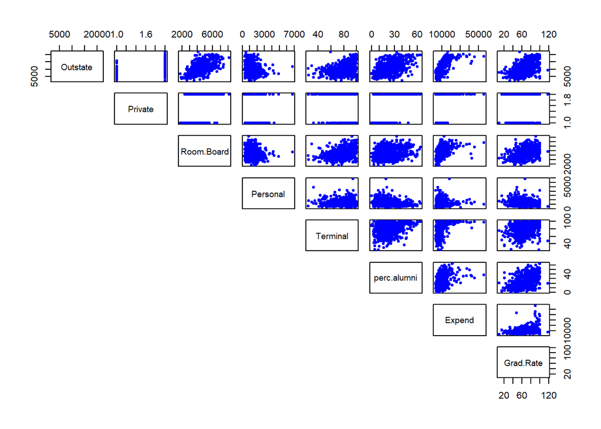

```r
pairs(Outstate~Private+Room.Board+Personal+Terminal+perc.alumni+Expend+Grad.Rate, lower.panel = NULL, col='blue', pch=20)
```

**3. Fit cubic splines to each of the bivariate relationships identiﬁed in (2) and overlay the ﬁts on new graphs of just these variables. Be sure specify how many knots you want. Comment on whether these ﬁts aﬀect your answer to (2).**

```r
PersonalLims=range(Personal)
Personal.grid=seq(from=PersonalLims[1],to=PersonalLims[2])

#knots=2
model.err=NULL
for(i in 3:8){
fit=lm(Outstate~bs(Personal,df=i),data=College[train,])
pred=predict(fit, newdata = list(Personal=Personal.grid))
model.err = c(model.err, mean((Outstate[test]-pred)^2))
}
model.err
```

```
## [1] 17206965 16518465 16340695 17586266 19443128 20445383
```

```r
#knots= 1 or 4
set.seed(17)
cv.error=NULL
for (i in 3:8){
  glm.fit=glm(Outstate~bs(Personal, df=i),data=College)
  cv.error= c(cv.error, cv.glm(College,glm.fit,K=5)$delta[1])
}
cv.error
```

```
## [1] 17599446 14556957 16197250 14835657 14404769 14891321
```

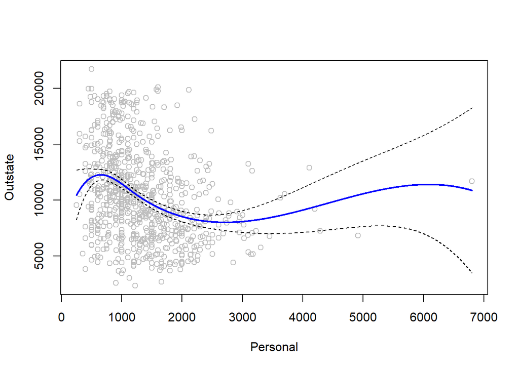

```r
best.fit = lm(Outstate~bs(Personal, df=4), data=College)

P.preds=predict(best.fit,newdata=list(Personal=Personal.grid),se=TRUE)
se.bands=cbind(P.preds$fit + 2*P.preds$se.fit, P.preds$fit -2*P.preds$se.fit)

{plot(Personal,Outstate,col="gray")
lines(Personal.grid,P.preds$fit,lwd=2, col="blue")
lines(Personal.grid,P.preds$fit+2*P.preds$se ,lty="dashed")
lines(Personal.grid,P.preds$fit-2*P.preds$se ,lty="dashed")}
```

```r
TerminalLims=range(Terminal)
Terminal.grid=seq(from=TerminalLims[1],to=TerminalLims[2])

set.seed(17)
cv.error=NULL
for (i in 3:8){
  glm.fit=glm(Outstate~bs(Terminal, df=i),data=College)
  cv.error= c(cv.error, cv.glm(College, glm.fit,K=5)$delta[1])
}
cv.error
```

```
## [1] 12747914 12876070 12819398 12796125 12825099 12669039
```

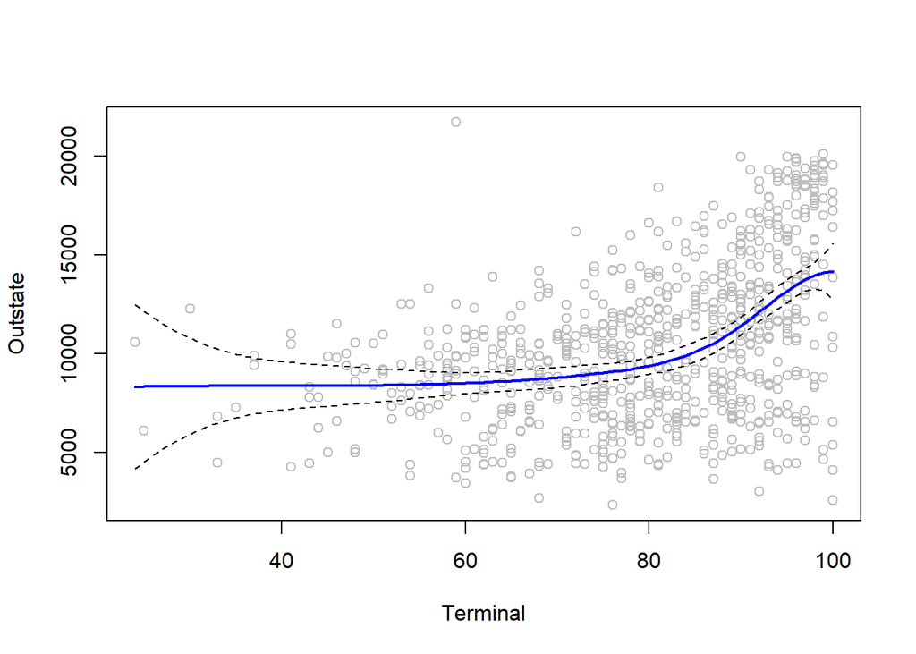

```r
best.fit = lm(Outstate~bs(Terminal, df=5), data=College)

P.preds=predict(best.fit,newdata=list(Terminal=Terminal.grid),se=TRUE)
se.bands=cbind(P.preds$fit + 2*P.preds$se.fit, P.preds$fit -2*P.preds$se.fit)


{plot(Terminal,Outstate,col="gray")
lines(Terminal.grid,P.preds$fit,lwd=2, col="blue")
lines(Terminal.grid,P.preds$fit+2*P.preds$se ,lty="dashed")
lines(Terminal.grid,P.preds$fit-2*P.preds$se ,lty="dashed")}
```

```r
ExpendLims=range(Expend)
Expend.grid=seq(from=ExpendLims[1],to=ExpendLims[2])

set.seed(17)
cv.error=NULL
for (i in 3:8){
  glm.fit=glm(Outstate~bs(Expend, df=i),data=College)
  cv.error= c(cv.error, cv.glm(College, glm.fit,K=5)$delta[1])
}
cv.error
```

```
## [1] 6659920 6381216 6387055 6356572 6468550 6476029
```

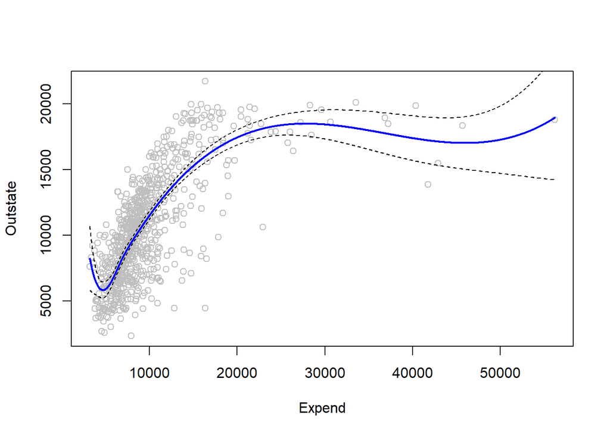

```r
best.fit = lm(Outstate~bs(Expend, df=6), data=College)

P.preds=predict(best.fit,newdata=list(Expend=Expend.grid),se=TRUE)
se.bands=cbind(P.preds$fit + 2*P.preds$se.fit, P.preds$fit -2*P.preds$se.fit)


{plot(Expend,Outstate,col="gray")
lines(Expend.grid,P.preds$fit,lwd=2, col="blue")
lines(Expend.grid,P.preds$fit+2*P.preds$se ,lty="dashed")
lines(Expend.grid,P.preds$fit-2*P.preds$se ,lty="dashed")}
```

```r
GradLims=range(Grad.Rate)
Grad.grid=seq(from=GradLims[1],to=GradLims[2])

set.seed(17)
cv.error=NULL
for (i in 3:8){
  glm.fit=glm(Outstate~bs(Grad.Rate, df=i),data=College)
  cv.error= c(cv.error, cv.glm(College, glm.fit,K=5)$delta[1])
}
cv.error
```

```
## [1] 10621713 10569632 10607769 10856172 13190293 14833979
```

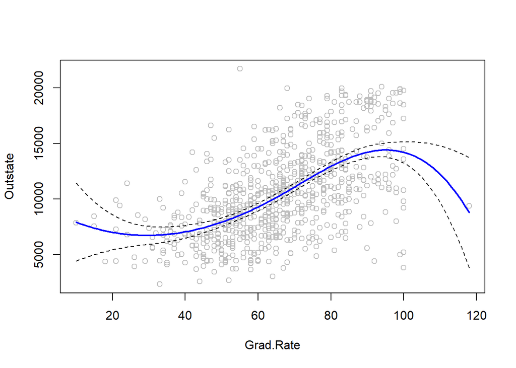

```r
best.fit = lm(Outstate~bs(Grad.Rate, df=4), data=College)

P.preds=predict(best.fit,newdata=list(Grad.Rate=Grad.grid),se=TRUE)
se.bands=cbind(P.preds$fit + 2*P.preds$se.fit, P.preds$fit -2*P.preds$se.fit)


{plot(Grad.Rate,Outstate,col="gray")
lines(Grad.grid,P.preds$fit,lwd=2, col="blue")
lines(Grad.grid,P.preds$fit+2*P.preds$se ,lty="dashed")
lines(Grad.grid,P.preds$fit-2*P.preds$se ,lty="dashed")}
```

**4. Fit a GAM on the training data, using out-of-state tuition as the response and the features selected in the previous steps as the predictors. Plot the results, and explain your ﬁndings.**

- From the plots we can see that our model suggest that holding Pct. Faculty with a terminal degree, Instructional expenditure per student, and Graduation rate fixed, that as estimated personal spending increases Out of state tuition decreases convexly and then changes to a linear relationship.
- For the terminal variable we can interpret its plot as holding all else constant as the number of terminal degrees held at a university increases the out of state tuition decreases in a cubic fashion, increasing its slope durastically for larger values of terminal.
- For the expenditure per student we can see that our model suggest that as this increases Out of state tuition rises rapidly before leveling off and not changing much after a certain level is reached, holding all else equal in the model.
- The Grad.Rate variables plot suggest that as the graduation rate increases the out of state tuition will rise in a mild cubic fashion before decreasing slightly at very high levels of graduation rates.

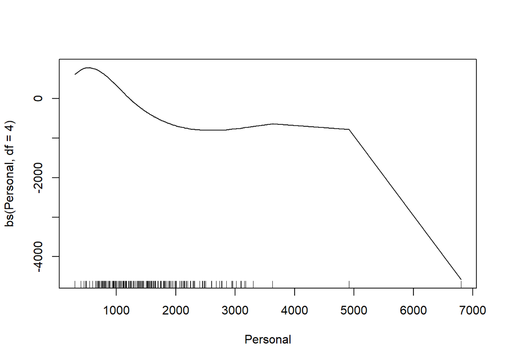

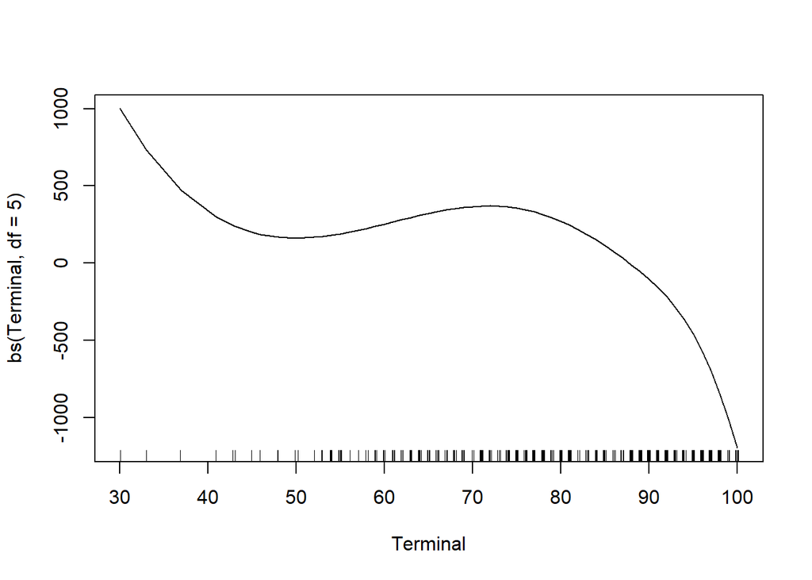

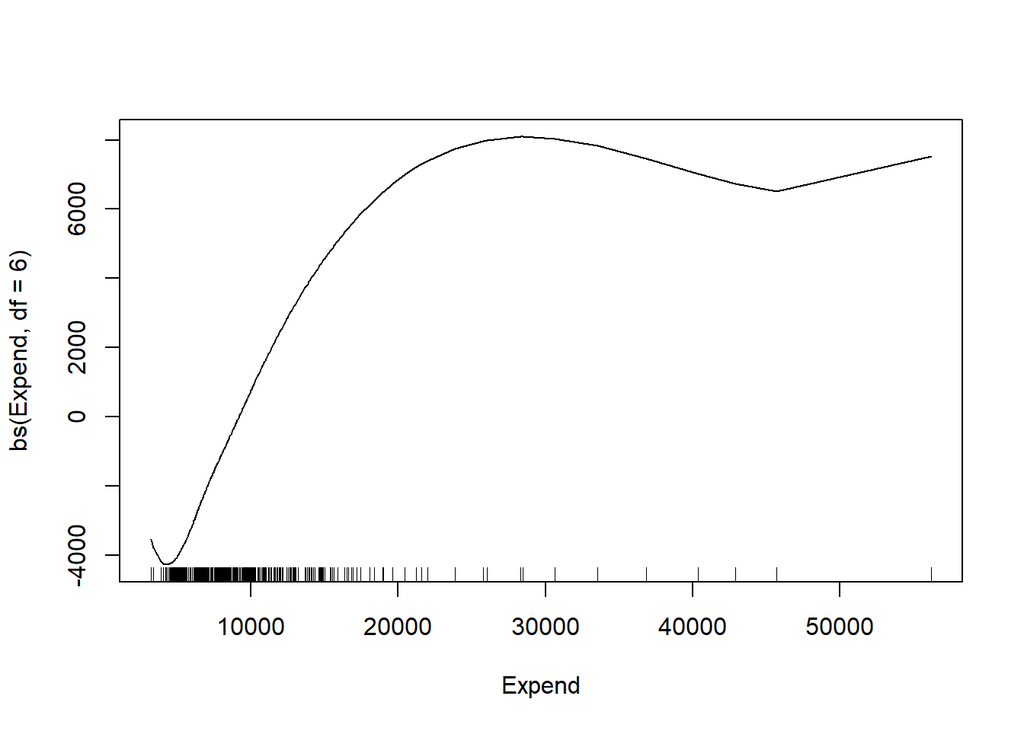

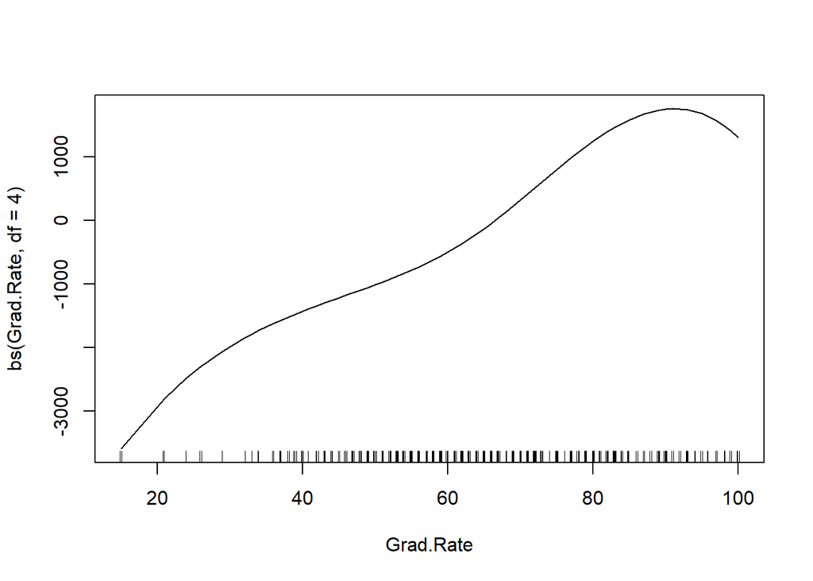

```r
gam1 = gam(Outstate~bs(Personal, df=4) + bs(Terminal, df=5) + bs(Expend, df=6) + bs(Grad.Rate, df=4), data=College[train,])
plot(gam1)
```

**5. Apply the model to the test set and report the test error**

```r
g.preds = predict(gam1, newdata=College[test,])
test.error = mean((Outstate[test] - g.preds)^2)
test.error
```

```
## [1] 4655314
```

# Problem 2.

**6. Produce a scatterplot matrix which includes all of the variables in the data set.**

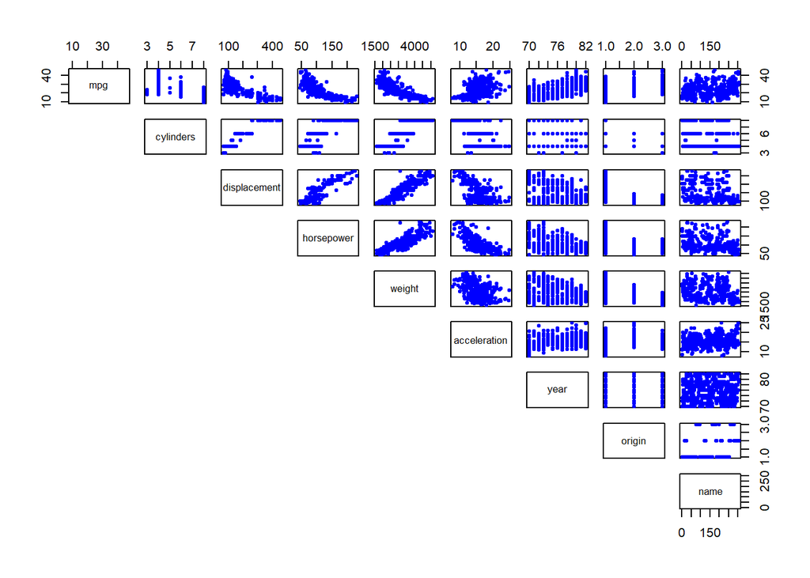

```r
attach(Auto)
pairs(mpg~.,data=Auto, lower.panel=NULL, col='blue', pch=20)
```

**7. Compute the matrix of correlations between the variables using the function cor(). You will need to exclude the name variable, which is qualitative.**

```r
cor(Auto[-9])
```

```
##                     mpg  cylinders displacement horsepower     weight
## mpg           1.0000000 -0.7776175   -0.8051269 -0.7784268 -0.8322442
## cylinders    -0.7776175  1.0000000    0.9508233  0.8429834  0.8975273
## displacement -0.8051269  0.9508233    1.0000000  0.8972570  0.9329944
## horsepower   -0.7784268  0.8429834    0.8972570  1.0000000  0.8645377
## weight       -0.8322442  0.8975273    0.9329944  0.8645377  1.0000000
## acceleration  0.4233285 -0.5046834   -0.5438005 -0.6891955 -0.4168392
## year          0.5805410 -0.3456474   -0.3698552 -0.4163615 -0.3091199
## origin        0.5652088 -0.5689316   -0.6145351 -0.4551715 -0.5850054
##              acceleration       year     origin
## mpg             0.4233285  0.5805410  0.5652088
## cylinders      -0.5046834 -0.3456474 -0.5689316
## displacement   -0.5438005 -0.3698552 -0.6145351
## horsepower     -0.6891955 -0.4163615 -0.4551715
## weight         -0.4168392 -0.3091199 -0.5850054
## acceleration    1.0000000  0.2903161  0.2127458
## year            0.2903161  1.0000000  0.1815277
## origin          0.2127458  0.1815277  1.0000000
```

**8. Use the lm() function to perform a multiple linear regression with mpg as the response and all other variables except name as the predictors. Use the summary() function to print the results. Comment on the output in the following ways:**

- **a) Is there a relationship between the predictors and the response?**
  - For some of the variables it appears that there is indeed a relationship, however quite a few coefficient estimates are close to 0 and non significant in this model, suggesting not all predictors have a linear relationship with the response.
- **b) Which predictors appear to have a statistically signiﬁcant relationship to the response?**
  - Displacement, Weight, Year, and Origin all appear to be significantly different from 0.
- **c) What does the coeﬃcient for year suggest?**
  - The coefficient on year suggest that a car that was built this year will get on average .75 mpg more than a similar vehicle from the year prior.

```r
mod1 = lm(mpg~.-name, data=Auto)
summary(mod1)
```

```
##
## Call:
## lm(formula = mpg ~ . - name, data = Auto)
##
## Residuals:
##     Min      1Q  Median      3Q     Max
## -9.5903 -2.1565 -0.1169  1.8690 13.0604
##
## Coefficients:
##                Estimate Std. Error t value Pr(>|t|)
## (Intercept)  -17.218435   4.644294  -3.707  0.00024 ***
## cylinders     -0.493376   0.323282  -1.526  0.12780
## displacement   0.019896   0.007515   2.647  0.00844 **
## horsepower    -0.016951   0.013787  -1.230  0.21963
## weight        -0.006474   0.000652  -9.929  < 2e-16 ***
## acceleration   0.080576   0.098845   0.815  0.41548
## year           0.750773   0.050973  14.729  < 2e-16 ***
## origin         1.426141   0.278136   5.127 4.67e-07 ***
## ---
## Signif. codes:  0 '***' 0.001 '**' 0.01 '*' 0.05 '.' 0.1 ' ' 1
##
## Residual standard error: 3.328 on 384 degrees of freedom
## Multiple R-squared:  0.8215, Adjusted R-squared:  0.8182
## F-statistic: 252.4 on 7 and 384 DF,  p-value: < 2.2e-16
```

**9. Produce diagnostic plots of the linear regression ﬁt. Comment on any problems you see with the ﬁt. Do the residual plots suggest any unusually large outliers? Does the leverage plot identify any observations with unusually high leverage?**

- It appears that our assumption of linearity may be violated as seen in the Residuals vs. Fitted plot, we can see a clear bowing effect in the middle, perhaps a transformation or use of GAM could help this solve this issue.
- From our Scale-Location plot we can see that there are not any major signs of heteroskedasticity
- Observation 323, 326, and 327 appear to be unusually large outliers.
- Observation 327, 394, and 14 appear to show signs of high leverage.

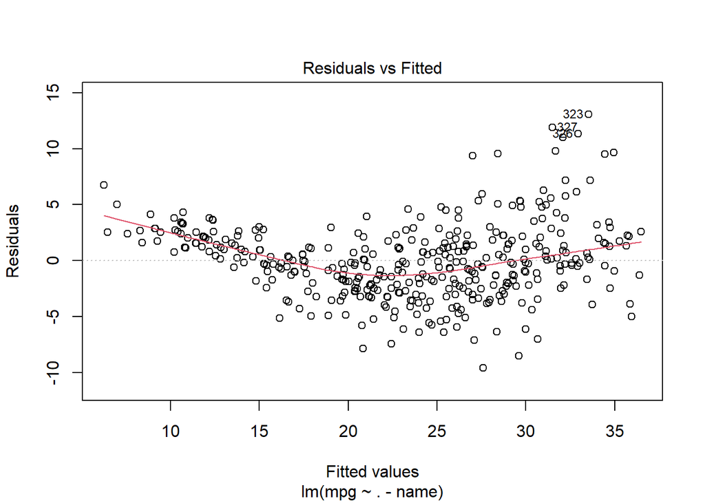

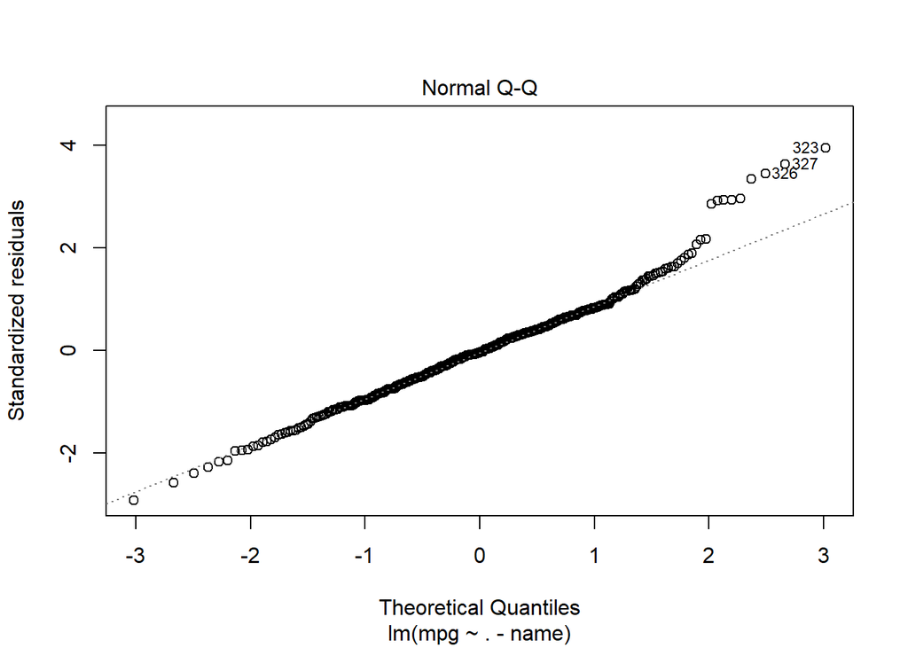

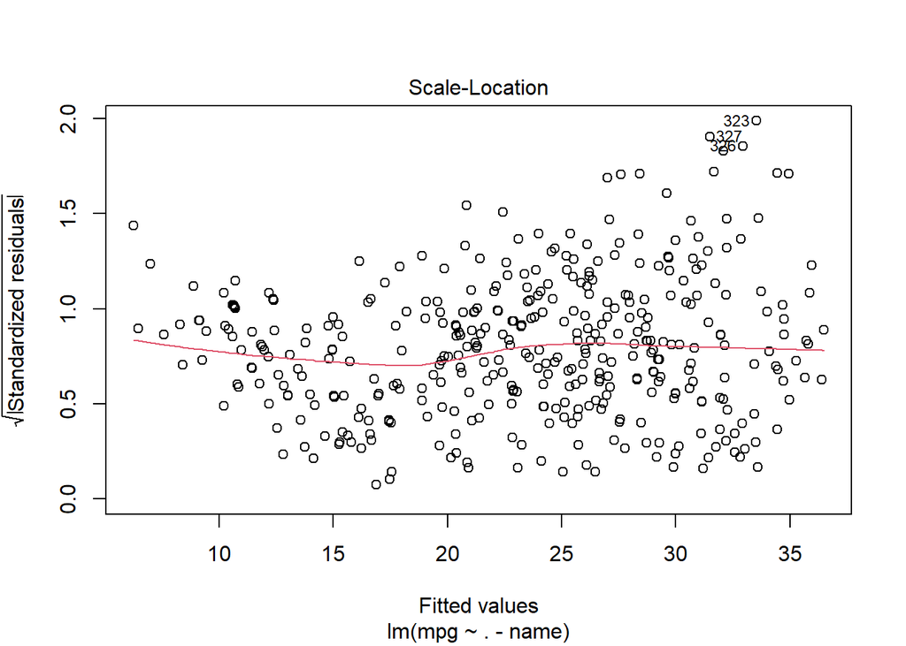

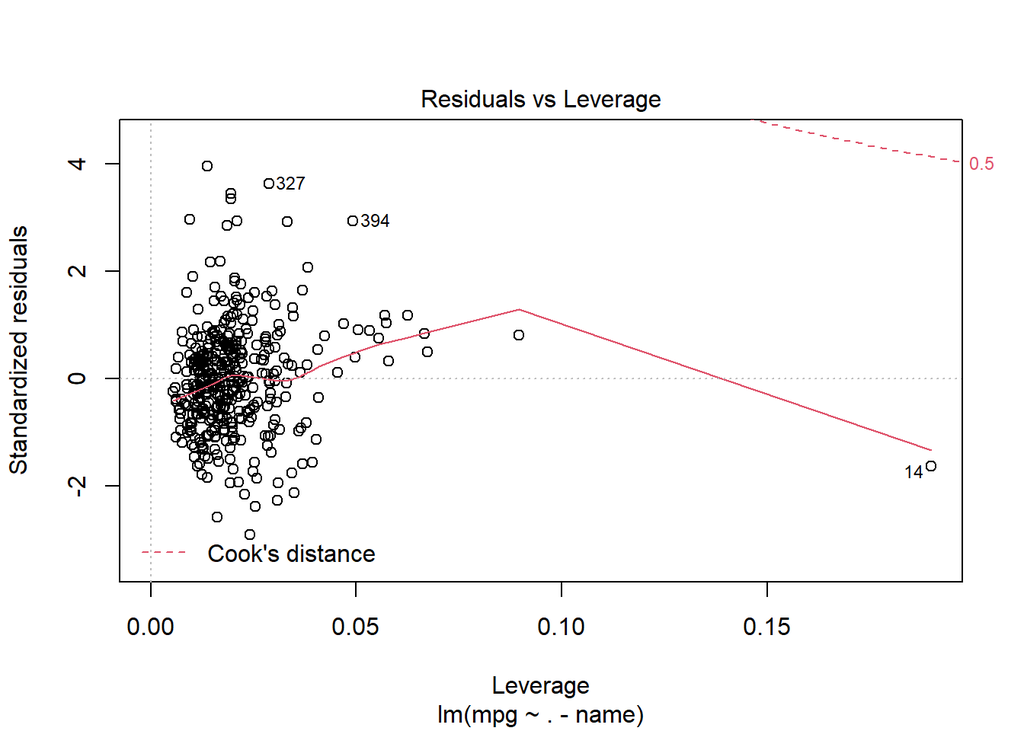

```r
plot(mod1)
```

**10. Use the * and : symbols to ﬁt linear regression models with interaction eﬀects. Do any interactions appear to be statistically signiﬁcant?**

```r
mod2 = lm(mpg~(.-name)^2, data=Auto)
summary(mod2)
```

```
##
## Call:
## lm(formula = mpg ~ (. - name)^2, data = Auto)
##
## Residuals:
##     Min      1Q  Median      3Q     Max
## -7.6303 -1.4481  0.0596  1.2739 11.1386
##
## Coefficients:
##                             Estimate Std. Error t value Pr(>|t|)
## (Intercept)                3.548e+01  5.314e+01   0.668  0.50475
## cylinders                  6.989e+00  8.248e+00   0.847  0.39738
## displacement              -4.785e-01  1.894e-01  -2.527  0.01192 *
## horsepower                 5.034e-01  3.470e-01   1.451  0.14769
## weight                     4.133e-03  1.759e-02   0.235  0.81442
## acceleration              -5.859e+00  2.174e+00  -2.696  0.00735 **
## year                       6.974e-01  6.097e-01   1.144  0.25340
## origin                    -2.090e+01  7.097e+00  -2.944  0.00345 **
## cylinders:displacement    -3.383e-03  6.455e-03  -0.524  0.60051
## cylinders:horsepower       1.161e-02  2.420e-02   0.480  0.63157
## cylinders:weight           3.575e-04  8.955e-04   0.399  0.69000
## cylinders:acceleration     2.779e-01  1.664e-01   1.670  0.09584 .
## cylinders:year            -1.741e-01  9.714e-02  -1.793  0.07389 .
## cylinders:origin           4.022e-01  4.926e-01   0.816  0.41482
## displacement:horsepower   -8.491e-05  2.885e-04  -0.294  0.76867
## displacement:weight        2.472e-05  1.470e-05   1.682  0.09342 .
## displacement:acceleration -3.479e-03  3.342e-03  -1.041  0.29853
## displacement:year          5.934e-03  2.391e-03   2.482  0.01352 *
## displacement:origin        2.398e-02  1.947e-02   1.232  0.21875
## horsepower:weight         -1.968e-05  2.924e-05  -0.673  0.50124
## horsepower:acceleration   -7.213e-03  3.719e-03  -1.939  0.05325 .
## horsepower:year           -5.838e-03  3.938e-03  -1.482  0.13916
## horsepower:origin          2.233e-03  2.930e-02   0.076  0.93931
## weight:acceleration        2.346e-04  2.289e-04   1.025  0.30596
## weight:year               -2.245e-04  2.127e-04  -1.056  0.29182
## weight:origin             -5.789e-04  1.591e-03  -0.364  0.71623
## acceleration:year          5.562e-02  2.558e-02   2.174  0.03033 *
## acceleration:origin        4.583e-01  1.567e-01   2.926  0.00365 **
## year:origin                1.393e-01  7.399e-02   1.882  0.06062 .
## ---
## Signif. codes:  0 '***' 0.001 '**' 0.01 '*' 0.05 '.' 0.1 ' ' 1
##
## Residual standard error: 2.695 on 363 degrees of freedom
## Multiple R-squared:  0.8893, Adjusted R-squared:  0.8808
## F-statistic: 104.2 on 28 and 363 DF,  p-value: < 2.2e-16
```

**11. With your ﬁnal model from (10), perform a bootstrap procedure to estimate the standard errors of your model coeﬃcients. Comment on how the results compare to your previous output.**

```r
boot.fn=function(data,index){
return(coef(lm(mpg~(.-name)^2, data=Auto,subset=index)))
}

set.seed(1)
boots = boot(Auto,boot.fn,1000)
boots
```

```
##
## ORDINARY NONPARAMETRIC BOOTSTRAP
##
##
## Call:
## boot(data = Auto, statistic = boot.fn, R = 1000)
##
##
## Bootstrap Statistics :
##           original        bias     std. error
## t1*   3.547889e+01 -5.104099e+00 5.973970e+01
## t2*   6.988576e+00 -1.074423e-01 8.046317e+00
## t3*  -4.785387e-01  2.037601e-02 2.200329e-01
## t4*   5.034339e-01 -4.571276e-03 4.102653e-01
## t5*   4.132886e-03 -3.538692e-04 1.736103e-02
## t6*  -5.859173e+00  1.696986e-01 2.415376e+00
## t7*   6.974303e-01  6.648055e-02 7.097001e-01
## t8*  -2.089557e+01  1.093455e+00 8.198624e+00
## t9*  -3.383263e-03 -6.692464e-04 6.854143e-03
## t10*  1.161333e-02  1.370066e-03 1.997676e-02
## t11*  3.574630e-04  1.267192e-05 8.104311e-04
## t12*  2.778720e-01  3.539600e-03 1.435039e-01
## t13* -1.741259e-01  6.515496e-04 9.941623e-02
## t14*  4.021682e-01 -2.585068e-02 6.537759e-01
## t15* -8.490622e-05 -1.804081e-05 2.438010e-04
## t16*  2.471868e-05  1.227603e-06 1.272855e-05
## t17* -3.478995e-03 -2.591022e-04 3.186820e-03
## t18*  5.933802e-03 -1.484006e-04 3.224252e-03
## t19*  2.398113e-02 -3.851104e-03 2.730291e-02
## t20* -1.968430e-05 -1.758202e-06 2.843848e-05
## t21* -7.212739e-03  1.412157e-05 4.729138e-03
## t22* -5.837506e-03  1.203527e-04 4.971304e-03
## t23*  2.232507e-03 -3.453091e-03 3.752095e-02
## t24*  2.346194e-04  1.271837e-05 2.211041e-04
## t25* -2.245237e-04 -3.458023e-06 2.317930e-04
## t26* -5.788475e-04  3.207700e-04 2.089251e-03
## t27*  5.562151e-02 -2.276476e-03 2.972206e-02
## t28*  4.583161e-01 -9.586262e-03 1.985996e-01
## t29*  1.392570e-01 -1.128193e-02 8.203941e-02
```

```r
se = sqrt(diag(vcov(mod2)))
se
```

```
##               (Intercept)                 cylinders              displacement
##              5.313579e+01              8.247971e+00              1.893534e-01
##                horsepower                    weight              acceleration
##              3.469994e-01              1.759419e-02              2.173621e+00
##                      year                    origin    cylinders:displacement
##              6.096703e-01              7.097091e+00              6.455096e-03
##      cylinders:horsepower          cylinders:weight    cylinders:acceleration
##              2.419810e-02              8.954933e-04              1.664216e-01
##            cylinders:year          cylinders:origin   displacement:horsepower
##              9.714126e-02              4.926224e-01              2.884624e-04
##       displacement:weight displacement:acceleration         displacement:year
##              1.469558e-05              3.341735e-03              2.390716e-03
##       displacement:origin         horsepower:weight   horsepower:acceleration
##              1.946528e-02              2.923954e-05              3.719449e-03
##           horsepower:year         horsepower:origin       weight:acceleration
##              3.938466e-03              2.930144e-02              2.288563e-04
##               weight:year             weight:origin         acceleration:year
##              2.126812e-04              1.591174e-03              2.558175e-02
##       acceleration:origin               year:origin
##              1.566597e-01              7.398950e-02
```